# Text analysis of Trump tweets

Anton Antonov  
[MathematicaVsR at GitHub](https://github.com/antononcube/MathematicaVsR)  
November, 2016

# Introduction

This R-Markdown notebook was made for the R-part of the MathematicaVsR project [“Text analysis of Trump tweets”](https://github.com/antononcube/MathematicaVsR/tree/master/Projects/TextAnalysisOfTrumpTweets).

The project is based in the blog post [1], and this R-notebook uses the data from [1] and provide statistics extensions or alternatives. For conclusions over those statistics see [1].

# Load libraries

Here are the libraries used in this R-notebook. In addition to those in [1] the libraries “vcd” and “arules” are used.

```r
library(plyr)
library(dplyr)
library(tidyr)
library(ggplot2)
library(lubridate)
library(arules)
library(vcd)
```

# Getting data

We are not going to repeat the Twitter messages ingestion done in [1] – we are going to use the data frame ingestion result provided in [1].

```r
load(url("http://varianceexplained.org/files/trump_tweets_df.rda"))
#load("./trump_tweets_df.rda")
```

# Data wrangling – extracting source devices and adding time tags

As it is done in the blog post [1] we project and clean the data:

```r
tweets <- trump_tweets_df %>%
  select(id, statusSource, text, created) %>%
  extract(statusSource, "source", "Twitter for (.*?)<") %>%
  filter(source %in% c("Android", "iPhone"))
```

Next we add time tags derived from the time-stamp column “created”. For the analysis that follows only the dates, hours, and the weekdays are needed.

```r
tweets <- cbind( tweets, date = as.Date(tweets$created), hour = hour(with_tz(tweets$created, "EST")), weekday = weekdays(as.Date(tweets$created)) )
```

```r
summary(as.data.frame(unclass(tweets)))
```

```
                  id           source
 676494179216805888:   1   Android:762
 676509769562251264:   1   iPhone :628
 678442470720577537:   1
 678446032599040001:   1
 678490367285678081:   1
 680492103722479616:   1
 (Other)           :1384
                                                                                                                                         text
 MAKE AMERICA GREAT AGAIN!                                                                                                                 :   5
 . #RepMikeKelly  Great job on @foxandfriends this morning. Thank you for the nice words!                                                  :   1
 .@AC360  Anderson, so amazing. Your mother is, and always has been, an incredible woman!                                                  :   1
 .@AndreBauer  Great job and advice on @CNN  @jaketapper  Thank you!                                                                       :   1
 .@AnnCoulter has been amazing. We will win and establish strong borders, we will build a WALL and Mexico will pay. We will be great again!:   1
 .@Borisep was great on @JudgeJeanine tonight. Very smart commentary that will prove to be correct!                                        :   1
 (Other)                                                                                                                                   :1380
    created                         date                 hour            weekday
 Min.   :2015-12-14 20:09:15   Min.   :2015-12-14   Min.   : 0.00   Friday   :200
 1st Qu.:2016-03-20 19:59:25   1st Qu.:2016-03-20   1st Qu.: 8.00   Monday   :164
 Median :2016-05-18 01:00:49   Median :2016-05-18   Median :14.00   Saturday :187
 Mean   :2016-05-11 17:50:36   Mean   :2016-05-11   Mean   :13.44   Sunday   :171
 3rd Qu.:2016-07-04 13:52:59   3rd Qu.:2016-07-04   3rd Qu.:18.00   Thursday :181
 Max.   :2016-08-08 15:20:44   Max.   :2016-08-08   Max.   :23.00   Tuesday  :217
                                                                    Wednesday:270
```

# Time series and time related distributions

Simple time series with moving average.

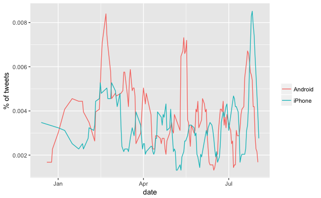

```r
qdf <- ddply( tweets, c("source","date"), function(x) { data.frame( source = x$source[1], date = x$date[1], count = nrow(x), fraction = nrow(x) / nrow(tweets) ) } )
windowSize <- 6
qdf <-
  ddply( qdf, "source", function(x) {
    x = x[ order(x$date), ]; cs <- cumsum(x$fraction);
    cbind( x[1:(nrow(x)-windowSize),], fma = ( cs[(windowSize+1):length(cs)] - cs[1:(length(cs)-windowSize)] ) / windowSize ) }
  )
ggplot(qdf) + geom_line( aes( x = date, y = fma, color = source ) ) + labs(x = "date", y = "% of tweets", color = "")
```

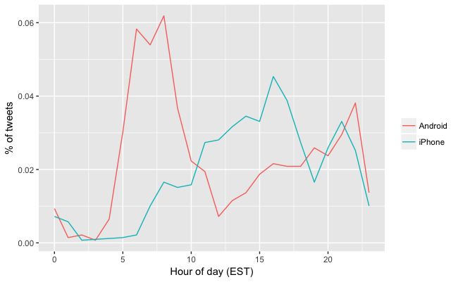

```r
qdf <- ddply( tweets, c("source", "hour"), function(x) { data.frame( source = x$source[1], hour = x$hour[1], count = nrow(x), fraction = nrow(x) / nrow(tweets) ) } )
ggplot(qdf) + geom_line( aes( x = hour, y = fraction, color = source ) ) + labs(x = "Hour of day (EST)", y = "% of tweets", color = "")
```

At this point we can also plot a mosaic plot of tweets` creation hours or weekdays with respect to device sources:

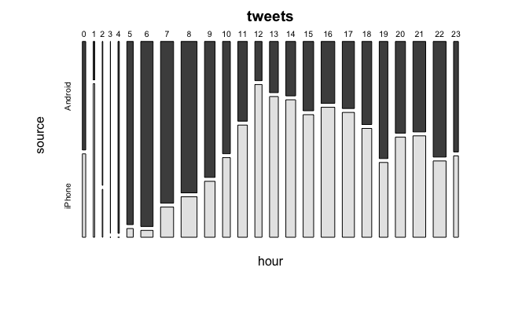

```r
mosaicplot( hour ~ source, tweets, dir = "h", color = TRUE )
```

[figure not shown]

# Comparison by used words

This section demonstrates a way to derive word-device associations that is alternative to the approach in [1]. The [Association rules learning](https://en.wikipedia.org/wiki/Association_rule_learning) algorithm Apriori is used through the package [“arules”](https://cran.r-project.org/web/packages/arules/index.html).

First we split the tweet messages into bags of words (baskets).

```r
sres <- strsplit( iconv(tweets$text),"\\s")
sres <- llply( sres, function(x) { x <- unique(x); x[nchar(x)>2] })
```

The package “arules” does not work directly with lists of lists. (In this case with a list of bags or words or baskets.) We have to derive a binary incidence matrix from the bags of words.

Here we add the device tags to those bags of words and derive a long form of tweet-index and word pairs:

```r
sresDF <-
  ldply( 1:length(sres), function(i) {
    data.frame( index = i, word = c( tweets$source[i], sres[i][[1]]) )
  })
```

Next we find the contingency matrix for index vs. word:

```r
wordsCT <- xtabs( ~ index + word, sresDF, sparse = TRUE)
```

At this point we can use the Apriori algorithm of the package:

```r
rulesRes <- apriori( as.matrix(wordsCT), parameter = list(supp = 0.01, conf = 0.6, maxlen = 2, target = "rules"))
```

```
Apriori

Parameter specification:
 confidence minval smax arem  aval originalSupport maxtime support minlen maxlen target   ext
        0.6    0.1    1 none FALSE            TRUE       5    0.01      1      2  rules FALSE

Algorithmic control:
 filter tree heap memopt load sort verbose
    0.1 TRUE TRUE  FALSE TRUE    2    TRUE

Absolute minimum support count: 13

set item appearances ...[0 item(s)] done [0.00s].
set transactions ...[6572 item(s), 1390 transaction(s)] done [0.00s].
sorting and recoding items ... [184 item(s)] done [0.00s].
creating transaction tree ... done [0.00s].
checking subsets of size 1 2
```

```
Mining stopped (maxlen reached). Only patterns up to a length of 2 returned!
```

```
 done [0.00s].
writing ... [171 rule(s)] done [0.00s].
creating S4 object  ... done [0.00s].
```

Here are association rules for “Android” sorted by confidence in descending order:

```r
inspect( subset( sort(rulesRes, by="confidence"), subset = rhs %in% "Android" & confidence > 0.78) )
```

```
     lhs                   rhs       support    confidence lift
[1]  {A.M.}             => {Android} 0.01007194 1.0000000  1.824147
[2]  {@megynkelly}      => {Android} 0.01726619 1.0000000  1.824147
[3]  {@realDonaldTrump} => {Android} 0.08057554 0.9911504  1.808004
[4]  {Wow,}             => {Android} 0.01510791 0.9545455  1.741231
[5]  {time}             => {Android} 0.01366906 0.9500000  1.732940
[6]  {done}             => {Android} 0.01223022 0.9444444  1.722805
[7]  {over}             => {Android} 0.01079137 0.9375000  1.710138
[8]  {president}        => {Android} 0.01007194 0.9333333  1.702537
[9]  {because}          => {Android} 0.01870504 0.9285714  1.693851
[10] {@CNN}             => {Android} 0.01726619 0.9230769  1.683828
[11] {were}             => {Android} 0.01510791 0.9130435  1.665526
[12] {beat}             => {Android} 0.01366906 0.9047619  1.650419
[13] {U.S.}             => {Android} 0.01294964 0.9000000  1.641732
[14] {win}              => {Android} 0.01870504 0.8965517  1.635442
```

[output cut: 36 more lines]

And here are association rules for “iPhone” sorted by confidence in descending order:

```r
iphRules <- inspect( subset( sort(rulesRes, by="confidence"), subset = rhs %in% "iPhone" & support > 0.01) )
```

```
     lhs                         rhs      support    confidence lift
[1]  {#TrumpPence16}          => {iPhone} 0.01007194 1.0000000  2.213376
[2]  {THANK}                  => {iPhone} 0.01223022 1.0000000  2.213376
[3]  {#ImWithYou}             => {iPhone} 0.01366906 1.0000000  2.213376
[4]  {#VoteTrump}             => {iPhone} 0.01582734 1.0000000  2.213376
[5]  {#AmericaFirst}          => {iPhone} 0.01942446 1.0000000  2.213376
[6]  {Join}                   => {iPhone} 0.02733813 1.0000000  2.213376
[7]  {#Trump2016}             => {iPhone} 0.12302158 0.9500000  2.102707
[8]  {#CrookedHillary}        => {iPhone} 0.01151079 0.9411765  2.083177
[9]  {soon!}                  => {iPhone} 0.01151079 0.9411765  2.083177
[10] {#MakeAmericaGreatAgain} => {iPhone} 0.06546763 0.9100000  2.014172
[11] {#MAGA}                  => {iPhone} 0.01151079 0.8888889  1.967445
[12] {Thank}                  => {iPhone} 0.12086331 0.7850467  1.737603
[13] {you}                    => {iPhone} 0.11151079 0.7142857  1.580983
[14] {tonight}                => {iPhone} 0.01366906 0.6785714  1.501934
[15] {AGAIN!}                 => {iPhone} 0.01798561 0.6410256  1.418831
[16] {New}                    => {iPhone} 0.02086331 0.6304348  1.395389
[17] {you!}                   => {iPhone} 0.02446043 0.6296296  1.393607
[18] {&amp;}                  => {iPhone} 0.03669065 0.6219512  1.376612
```

Generally speaking, the package “arules” is somewhat awkward to use. For example, extracting the words of the column “lhs” would require some wrangling:

```r
ws <- as.character(unclass(as.character(iphRules$lhs)))
gsub(pattern = "\\{|\\}", "", ws)
```

```
 [1] "#TrumpPence16"          "THANK"                  "#ImWithYou"             "#VoteTrump"             "#AmericaFirst"          "Join"
 [7] "#Trump2016"             "#CrookedHillary"        "soon!"                  "#MakeAmericaGreatAgain" "#MAGA"                  "Thank"
[13] "you"                    "tonight"                "AGAIN!"                 "New"                    "you!"                   "&amp;"
```

# References

[1] David Robinson, [“Text analysis of Trump’s tweets confirms he writes only the (angrier) Android half”](http://varianceexplained.org/r/trump-tweets/), (2016), [VarianceExplained.org](http://varianceexplained.org).